[figure not shown]

# Self Organizing Maps

Kannan Singaravelu

kannan.singaravelu@fitchlearning.com

# Self Organizing Maps

Self-organizing maps (SOM) are a class of unsupervised learning neural networks used for feature detection. SOM are used to project a high dimensional data into a smaller set and are used for dimensionality reduction.

SOMs differ from conventional artificial neural networks as they apply competitive learning when compared to error correlated learning, which involves backpropagation and gradient descent. In SOM, the training data has no labels and the map learns to differentiate and distinguish features based on similarities.

## SOM Algorithm

Step 1 : Initialize weights $w_{ij}$  
Step 2 : Calculate distance $d_{ij} = \sum (w_{ij} - x_i)^2 $  
Step 3 : Calcualte $w_{ij}(t+1) = w_{ij}(t) + \theta(t) \cdot \alpha(t) \cdot (x_i(t) - w_{ij}(t))$

where $x_i(t)$ is the characteristics of the samples, $\alpha(t)$ is a learning rate and $\theta(t)$ is the neighbourhood function.

The weights are adjusted iteratively from the Euclidean distance by updating the learning rate. The neuron whose weight vector is most similar to the input is called the best matching unit (BMU). Once the BMU has been determined, we then calculate which of the other nodes are within the BMU’s neighborhood. Nodes found within the radius are deemed to be inside the neighborhood of the BMU. This process is repeated until convergence or number of iterations.

## Implementation

```python
# Import libraries
import pandas as pd
import numpy as np

# SOM & Sklearn library
from minisom import MiniSom
from sklearn.preprocessing import MinMaxScaler

# Visualization library
import matplotlib.pyplot as plt
plt.style.use('fivethirtyeight')

# Ignore warnings
import warnings
warnings.filterwarnings('ignore')
```

## Load Data

```python
# Read cluster file saved locally
df = pd.read_csv('data/cluster.csv', index_col=0)
df
```

|  | Cluster | Companies Name | Companies | ATR | CHG |
| --- | --- | --- | --- | --- | --- |
| 0 | 0 | Visa Inc. | V | 1.505029 | 0.004790 |
| 1 | 0 | Microsoft | MSFT | 1.297601 | 0.004348 |
| 2 | 1 | 3M | MMM | 2.101351 | 0.002096 |
| 3 | 2 | Apple Inc. | AAPL | 0.683054 | 0.005884 |
| 4 | 2 | Verizon Communications | VZ | 0.605954 | 0.002339 |
| 5 | 2 | Cisco Systems | CSCO | 0.542990 | 0.001977 |
| 6 | 2 | The Coca-Cola Company | KO | 0.493957 | 0.002008 |
| 7 | 2 | Intel | INTC | 0.700276 | 0.002865 |
| 8 | 3 | Goldman Sachs | GS | 3.637879 | 0.001351 |
| 9 | 4 | UnitedHealth Group | UNH | 2.749258 | 0.005033 |
| 10 | 5 | Boeing | BA | 3.781579 | 0.004052 |
| 11 | 6 | Amgen | AMGN | 2.670555 | 0.003558 |
| 12 | 7 | Procter & Gamble | PG | 1.033288 | 0.002292 |
| 13 | 7 | Nike, Inc. | NKE | 0.973594 | 0.004777 |
| 14 | 7 | Merck & Co. | MRK | 0.865587 | 0.002460 |
| 15 | 7 | Johnson & Johnson | JNJ | 1.307901 | 0.002280 |
| 16 | 7 | Walmart | WMT | 1.120372 | 0.002466 |
| 17 | 7 | JPMorgan Chase | JPM | 1.311930 | 0.002658 |
| 18 | 8 | IBM | IBM | 2.094200 | 0.000940 |
| 19 | 9 | McDonald's | MCD | 1.650879 | 0.003108 |
| 20 | 9 | Honeywell | HON | 1.611824 | 0.003627 |
| 21 | 9 | The Travelers Companies | TRV | 1.425766 | 0.002259 |
| 22 | 9 | American Express | AXP | 1.427355 | 0.002617 |
| 23 | 9 | The Walt Disney Company | DIS | 1.485320 | 0.003183 |
| 24 | 10 | Salesforce | CRM | 2.206371 | 0.005697 |
| 25 | 11 | Caterpillar Inc. | CAT | 2.079727 | 0.003068 |
| 26 | 12 | Walgreens Boots Alliance | WBA | 1.120467 | 0.001044 |
| 27 | 13 | Chevron Corporation | CVX | 1.632494 | 0.001211 |
| 28 | 14 | The Home Depot | HD | 1.987204 | 0.005014 |

## Define Feature Matrix

```python
# Define feature matrix
X = df[['ATR', 'CHG']]

# Transfor feature matrix
scaler = MinMaxScaler()
X = scaler.fit_transform(X)
X
```

```
array([[0.30753898, 0.77864971],
       [0.2444453 , 0.6894365 ],
       [0.48892296, 0.2339478 ],
       [0.05751796, 1.        ],
       [0.03406623, 0.28296353],
       [0.01491451, 0.20981974],
       [0.        , 0.21604466],
       [0.06275625, 0.38932312],
       [0.95629079, 0.08316865],
       [0.68599786, 0.82785112],
       [1.        , 0.62939372],
       [0.6620585 , 0.52947676],
       [0.16404908, 0.27347769],
       [0.1458918 , 0.77602764],
       [0.11303924, 0.30752683],
       [0.24757848, 0.27114199],
       [0.1905374 , 0.30877877],
       [0.24880381, 0.34743124],
       [0.48674785, 0.        ],
       [0.3519025 , 0.43853121],
       [0.34002296, 0.54342061],
       [0.28342954, 0.26674555],
       [0.28391297, 0.33919906],
       [0.301544  , 0.45373582],
       [0.52086698, 0.96216043],
       [0.48234575, 0.43045945],
       [0.1905663 , 0.02108074],
       [0.34631029, 0.05492656],
       [0.45420295, 0.82414569]])
```

## Train SOM

```python
# Initialize a 15x15 SOM
som = MiniSom(15, 15, 2, learning_rate=0.5, sigma=5, random_seed=42)

# Initialize with randon weights
som.random_weights_init(X)

# Trains SOM with 10000 iterations
som.train_batch(X,10000, verbose=True)
```

```
 [ 10000 / 10000 ] 100% - 0:00:00 left
 quantization error: 0.06690404296473335
```

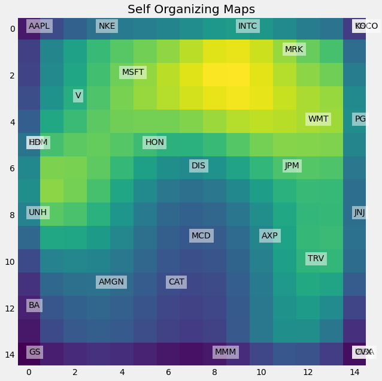

```python
# Plot SOM
plt.figure(figsize=(20, 10))
for ix in range(len(X)):
    winner = som.winner(X[ix])
    plt.text(winner[0], winner[1], df.Companies[ix], bbox=dict(facecolor='white', alpha=0.5, lw=0))
plt.imshow(som.distance_map())
plt.grid(False)
plt.title('Self Organizing Maps');
```

*Result of training the SOM with feature set X and labelling it at their respective SOM neurons.*

```python
# List the corresponding companies
for ix in range(len(X)):
    winner = som.winner(X[ix])
    print(winner[0], winner[1], df['Companies Name'][ix])
```

```
2 3 Visa Inc.
4 2 Microsoft
8 14 3M
0 0 Apple Inc.
14 0 Verizon Communications
14 0 Cisco Systems
14 0 The Coca-Cola Company
9 0 Intel
0 14 Goldman Sachs
0 8 UnitedHealth Group
0 12 Boeing
3 11 Amgen
14 4 Procter & Gamble
3 0 Nike, Inc.
11 1 Merck & Co.
14 8 Johnson & Johnson
12 4 Walmart
11 6 JPMorgan Chase
14 14 IBM
7 9 McDonald's
5 5 Honeywell
12 10 The Travelers Companies
10 9 American Express
7 6 The Walt Disney Company
0 5 Salesforce
6 11 Caterpillar Inc.
14 14 Walgreens Boots Alliance
14 14 Chevron Corporation
0 5 The Home Depot
```

# References

- [MiniSom](https://github.com/JustGlowing/minisom)
- [Python Resources](https://github.com/kannansingaravelu/PythonResources)

[Kannan Singaravelu](https://github.com/kannansingaravelu)  
Certificate in Quantitative Finance, June 2021